# Recommendation evaluation

Несколько слов про оценку рекомендации и сравнение моделей.

Сначала повторим все действия для построения модели

```r
library(jsonlite)
library(tidyverse)
library(recommenderlab)
library(readr)
```

Чтение данных

```r
movies <- read_csv("~/shared/minor2_2018/data/movies_cut.csv")[-1]
ratings <- read_csv("~/shared/minor2_2018/data/ratings_cut.csv")[-1]
ratings$customer_id %>% unique() %>% length()
```

```
## [1] 1000
```

Сохраним только оценки пользователей и фильмы

```r
rates = select(ratings, customer_id, movie_id, rating)
```

Преобразуем к таблице в “широком” формате

```r
rates = spread(rates, key = movie_id, value = rating)
```

Оставляем только оценки, поэтому переведем пользователей в имена строк. Преобразуем к нужному формату и уберем фильмы и пользователей с небольшим числом оценок

```r
rownames(rates) = rates$customer_id
rates = select(rates, -customer_id)
rates = as.matrix(rates)
r = as(rates, "realRatingMatrix")
ratings_movies <- r[rowCounts(r) > 20, colCounts(r) > 15]
```

Строим модель и предсказание. До этого мы делили на тестовую и обучающую выборки сами. Пакет `recommenderlab` предлагает нам “схемы”, которые сделают тоже самое.

При этом мы можем указать, какие оценки нас устраивают, т.е. в каком случае мы действительно хотим рекомендовать что-то пользователю. Рассмотрим вариант, когда подходят 4 и 5 (параметр goodRating). Параметр given показывает, сколько оценок пользователя мы будем использовать для сравнения (т.е. у всех пользователей должно быть не меньше given оцененных фильмов – нам нужны реальные оценки)

```r
set.seed(100)
eval_sets <- evaluationScheme(data = ratings_movies,
                              method = "split",
                              train = 0.8, # доля обучающей выборки
                              given = 15, # сколько оценок используется для  предсказания
                              goodRating = 4) # если предсказанная оценка < 4, то фильм не рекомендуем
```

Можем посмотреть как устроена наша обучающая выборка.

```r
getData(eval_sets, "train")
```

```
## 545 x 314 rating matrix of class 'realRatingMatrix' with 25068 ratings.
```

Можно посмотреть сколько оценок мы спрятали от нашей рекомендательной системы.

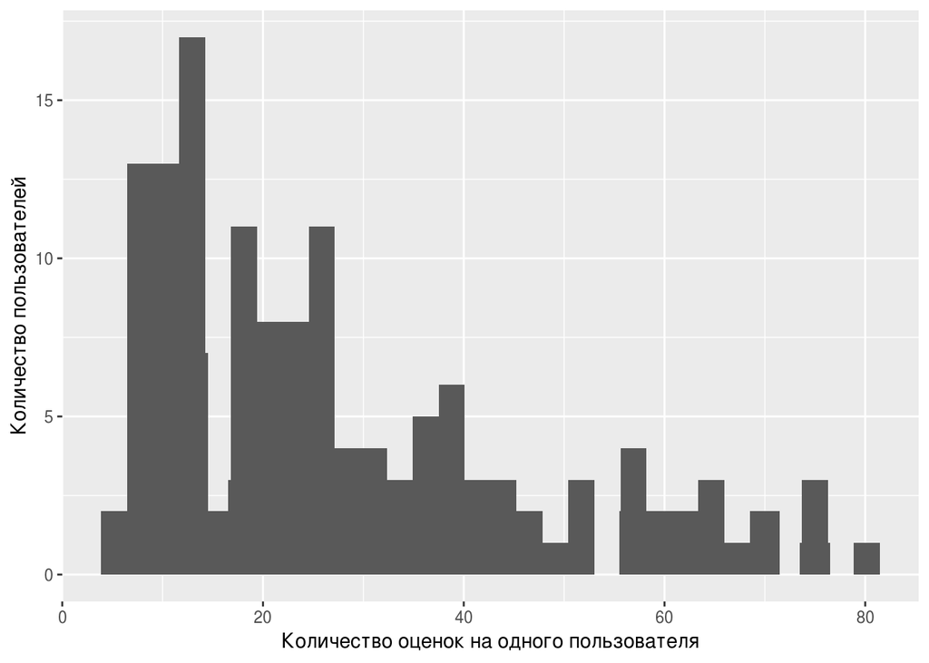

```r
qplot(rowCounts(getData(eval_sets, "unknown"))) + geom_histogram(binwidth = 1) +  ylab("Количество пользователей")  + xlab("Количество оценок на одного пользователя")
```

Распределение для “неспрятанных” оценок.

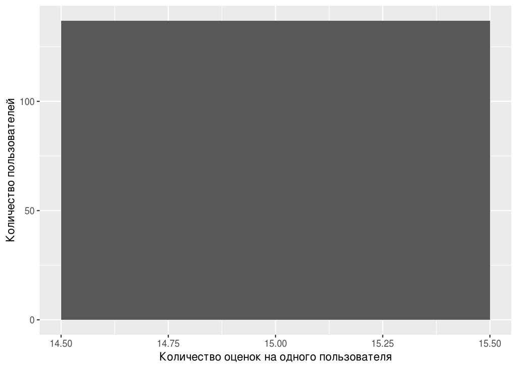

```r
qplot(rowCounts(getData(eval_sets, "known"))) + geom_histogram(binwidth = 1) + ylab("Количество пользователей") + xlab("Количество оценок на одного пользователя")
```

Какой-то странный график… На самом деле, все правильно – он показывает, что для каждого пользователя мы выбрали 15 оценок (фильмов)

```r
table(rowCounts(getData(eval_sets, "known")))
```

```
##
##  15
## 137
```

Строим модель на обучающей, предсказываем на тестовой

```r
recc_model <- Recommender(data = getData(eval_sets, "train"), method = "IBCF")
recc_predicted <- predict(object = recc_model, newdata = getData(eval_sets, "known"), n = 6, type = "ratings")
```

Мы сделали предсказание, давайте посмотрим на его качество. Качество = отклонение предсказания от реальности.

```r
eval_accuracy <- calcPredictionAccuracy(x = recc_predicted,
                                        # predicted values
                                        data = getData(eval_sets, "unknown"),
                                        byUser = T) # averaging for each user
head(eval_accuracy)
```

```
##            RMSE       MSE       MAE
## 10870 1.7320508 3.0000000 1.6666667
## 14974 0.7180603 0.5156105 0.4757951
## 31510 1.0200371 1.0404757 0.6995212
## 35074 2.2757105 5.1788581 1.8815814
## 39591 2.2240568 4.9464286 1.9642857
## 45733 1.4142136 2.0000000 1.3333333
```

```r
eval_accuracy2 <- calcPredictionAccuracy(x = recc_predicted,
                                         # predicted values
                                         data = getData(eval_sets, "unknown"),
                                         byUser = F) # not averaging for each user
eval_accuracy2
```

```
##     RMSE      MSE      MAE
## 1.448360 2.097748 1.094052
```

Мы получили какие-то оценки. Хорошие они или плохие? Мы можем сравнивать таким образом модели. Предположим, что для другой модели мы получили показатели RMSE = 1.2911565, MSE = 1.6670851, MAE = 0.9561163. Какая модель лучше?

**Ваша очередь:**

1. Постройте оценки методом UBSF. Сравните результаты
2. Поменяйте параметр given. Что-то изменилось? Что, если у пользователя просто нет такого чмсла фильмов.

### Общий принцип

Мы рассмотрели, как оценка реализована в пакете recommenderlab. В нем учитываются пропуски в оценках, число используемых оценок и т.д., но работает он только на результатах рекомендации по моделям, реализованным в этом пакете. Сейчас же посмотрим общий принцип оценки.

Рекомендации для пользователя 31510

```r
recc_model <- Recommender(data = ratings_movies, method = "IBCF")
recc_predicted <- predict(object = recc_model, newdata = ratings_movies, n = 5)
recc_user_1 <- recc_predicted@items[["31510"]]
movies_user_1 <- recc_predicted@itemLabels[recc_user_1]
names_movies_user_1 <- ratings$title[match(movies_user_1, ratings$movie_id)]
names_movies_user_1
```

```
## [1] "Seven Samurai"       "Whale Rider"         "Kicking & Screaming"
## [4] "Wonder Boys"         "25th Hour"
```

```r
recc_predicted@ratings[["31510"]]
```

```
## [1] 4.000000 4.000000 4.000000 4.000000 3.489783
```

Проверим, есть ли у этого пользователя реальные оценки этих фильмов

```r
filter(ratings, customer_id == 31510 & movie_id %in% as.numeric(movies_user_1))
```

```
## # A tibble: 0 x 6
## # … with 6 variables: customer_id <dbl>, rating <dbl>, rating_date <date>,
## #   movie_id <dbl>, movie_year <dbl>, title <chr>
```

Реальных оценок нет. Именно поэтому при оценке в пакете recommenderlab сначала отбираются те фильмы, на которые у пользователя есть оценка. Но как же тогда понять, подошла наша оценка или нет?

- для проверки используем только те фильмы, для которых есть правильные ответы
- опросы о качестве рекомендации (“понравилось ли вам”) / действия (посмотрел/не посмотрел, купил/не купил)
- сверка по внешним параметрам
  - жанры (если есть)
  - принадлежность к какому-то классу

Возьмем пользовательский топ-5 фильмов с имеющимися оценками. Но сначала преобразуем жанры

```r
source("/principal/courses/minor2_2018/2-tm-net/extract_json.R")
source("~/shared/minor2_2018/2-tm-net/extract_json.R")
movies = extract_json2(df = movies, col = "genres")

top5 = filter(ratings, customer_id == 31510) %>%
  top_n(5, rating) %>% inner_join(movies, by = "movie_id")

select(top5, genres_sep, movie_id)
```

```
## # A tibble: 11 x 2
##    genres_sep movie_id
##    <fct>         <dbl>
##  1 Drama           148
##  2 Romance         148
##  3 Drama           886
##  4 Music           886
##  5 Drama          1590
##  6 Comedy         3282
##  7 Drama          3282
##  8 Romance        3282
##  9 Comedy         4227
## 10 Action         4432
## 11 Crime          4432
```

А теперь посмотрим на жанры предсказания

```r
pred5 = movies %>% filter(movie_id %in% movies_user_1)

select(pred5,genres_sep, movie_id)
```

```
##    genres_sep movie_id
## 1      Action      872
## 2       Drama      872
## 3       Drama     3371
## 4      Family     3371
## 5       Crime     3626
## 6       Drama     3626
## 7      Comedy     4488
## 8       Drama     4488
## 9     Romance     3441
## 10     Comedy     3441
## 11     Family     3441
```

- какие выводы можно сделать?

Вопросы для размышления: * можно ли посчитать какой-то численный показатель по пользователю? * как обобщить на нескольких пользователей? * как это можно применить для content-based рекомендации? * как сравнить результаты content-based и коллаборативной фильтрации?